# Proxy GxE MR on breastfeeding and cognitive traits

2022-11-24

# 1 Introduction

This RMarkdown document reports the results of a proxy gene-by-environment Mendelian randomisation analysis of the influence of breastfeeding on educational attainment on the UK Biobank.

To model the data, we use the following fields:

- Year of birth (field 34);
- Sex (field 31 for self-reported sex, 22001 for genetically-derived sex);
- Breastfed as a baby or not (field 1677);
- Genetic principal components (field 22009);
- Fluid intelligence (fields 20191 and 20016);
- Age of completion of full time education (field 845);
- Indices of deprivation:
  - Townsend deprivation index (field 189);
  - Indices of multiple deprivation:
    - England (field 26410);
    - Scotland (field 26427);
    - Wales (field 26426);
- Metabolomics:
  - Total DHA (field 23450);
  - DHA/total fatty acids percentage (field 23457);
  - QC for DHA (field 26231);
- Genetics QC:
  - Batch (field 22000);
  - Plate (field 22004);
  - Well (field 22008).

# 2 Preparing the data

- **IQ**: we used the earliest available instance for either the online questionnaire or the assessment centre score, using age at completion and which scale is it coming from as a covariate; we expect the variable on the scale of origin to have an approximate effect of 1 (the online questionnaire had a question more in the assessment);
- *Breastfeeding*: coded as the reported breastfeeding status at the first instance;
- **Educational attainment**: we derive a measure of educational attainment as the number of years of education required to attain the highest degree, according to their ICSED level Carter et al. (2022);

  | Qualifications (as reported in UK Biobank) | ISCED | Years of education |
  | --- | --- | --- |
  | College or University degree | 5 | 20 |
  | NVQ or HND or HNC or equivalent | 5 | 19 |
  | Other professioal qualification e.g.: nursing, teaching | 4 | 15 |
  | A levels/AS levels or equivalent | 3 | 13 |
  | O levels/GCSEs or equivalent | 2 | 10 |
  | CSEs or equivalent | 2 | 10 |
  | None of the above | 1 | 7 |
  | Prefer not to answer | Excluded | NA |

- **Age**: we use the year of birth for educational attainment, or age at completion for the IQ score;

# 3 Table 1

|  | Total (N=405547) | rs1535 AA (N=178208) | rs1535 AG (N=179707) | rs1535 GG (N=47632) | rs174575 CC (N=217540) | rs174575 CG (N=158530) | rs174575 GG (N=29477) | rs174583 CC (N=171910) | rs174583 CT (N=183496) | rs174583 TT (N=50141) |
| --- | --- | --- | --- | --- | --- | --- | --- | --- | --- | --- |
| Sex |  |  |  |  |  |  |  |  |  |  |
| Male | 186817 (46.1%) | 82031 (46.0%) | 82877 (46.1%) | 21909 (46.0%) | 100108 (46.0%) | 72966 (46.0%) | 13743 (46.6%) | 79159 (46.0%) | 84630 (46.1%) | 23028 (45.9%) |
| Female | 218730 (53.9%) | 96177 (54.0%) | 96830 (53.9%) | 25723 (54.0%) | 117432 (54.0%) | 85564 (54.0%) | 15734 (53.4%) | 92751 (54.0%) | 98866 (53.9%) | 27113 (54.1%) |
| Year of birth |  |  |  |  |  |  |  |  |  |  |
| Mean (SD) | 1950 (8.12) | 1950 (8.16) | 1950 (8.09) | 1950 (8.10) | 1950 (8.15) | 1950 (8.10) | 1950 (8.06) | 1950 (8.15) | 1950 (8.11) | 1950 (8.11) |
| Median [Min, Max] | 1950 [1940, 1970] | 1950 [1940, 1970] | 1950 [1940, 1970] | 1950 [1940, 1970] | 1950 [1940, 1970] | 1950 [1940, 1970] | 1950 [1940, 1970] | 1950 [1940, 1970] | 1950 [1940, 1970] | 1950 [1940, 1970] |
| Breastfed as a baby |  |  |  |  |  |  |  |  |  |  |
| Yes | 223957 (55.2%) | 100086 (56.2%) | 97985 (54.5%) | 25886 (54.3%) | 121310 (55.8%) | 86662 (54.7%) | 15985 (54.2%) | 96009 (55.8%) | 100585 (54.8%) | 27363 (54.6%) |
| No | 85861 (21.2%) | 36811 (20.7%) | 38762 (21.6%) | 10288 (21.6%) | 45380 (20.9%) | 34089 (21.5%) | 6392 (21.7%) | 35847 (20.9%) | 39254 (21.4%) | 10760 (21.5%) |
| Do not know | 94872 (23.4%) | 40824 (22.9%) | 42681 (23.8%) | 11367 (23.9%) | 50296 (23.1%) | 37527 (23.7%) | 7049 (23.9%) | 39617 (23.0%) | 43338 (23.6%) | 11917 (23.8%) |
| Prefer not to answer | 387 (0.1%) | 223 (0.1%) | 131 (0.1%) | 33 (0.1%) | 249 (0.1%) | 122 (0.1%) | 16 (0.1%) | 200 (0.1%) | 148 (0.1%) | 39 (0.1%) |
| Missing | 470 (0.1%) | 264 (0.1%) | 148 (0.1%) | 58 (0.1%) | 305 (0.1%) | 130 (0.1%) | 35 (0.1%) | 237 (0.1%) | 171 (0.1%) | 62 (0.1%) |
| FI score (assessment centre) |  |  |  |  |  |  |  |  |  |  |
| Mean (SD) | 6.07 (2.15) | 5.98 (2.17) | 6.13 (2.14) | 6.16 (2.15) | 6.01 (2.16) | 6.12 (2.14) | 6.21 (2.15) | 6.01 (2.16) | 6.11 (2.14) | 6.13 (2.16) |
| Median [Min, Max] | 6.00 [0, 13.0] | 6.00 [0, 13.0] | 6.00 [0, 13.0] | 6.00 [0, 13.0] | 6.00 [0, 13.0] | 6.00 [0, 13.0] | 6.00 [0, 13.0] | 6.00 [0, 13.0] | 6.00 [0, 13.0] | 6.00 [0, 13.0] |
| Missing | 240630 (59.3%) | 105444 (59.2%) | 106802 (59.4%) | 28384 (59.6%) | 128793 (59.2%) | 94305 (59.5%) | 17532 (59.5%) | 101897 (59.3%) | 108911 (59.4%) | 29822 (59.5%) |
| FI score (online follow-up) |  |  |  |  |  |  |  |  |  |  |
| Mean (SD) | 5.45 (2.04) | 5.42 (2.05) | 5.47 (2.03) | 5.48 (2.04) | 5.42 (2.04) | 5.48 (2.04) | 5.51 (2.04) | 5.43 (2.05) | 5.46 (2.03) | 5.48 (2.05) |
| Median [Min, Max] | 5.00 [0, 13.0] | 5.00 [0, 13.0] | 6.00 [0, 13.0] | 6.00 [0, 12.0] | 5.00 [0, 13.0] | 6.00 [0, 13.0] | 6.00 [0, 12.0] | 5.00 [0, 13.0] | 6.00 [0, 13.0] | 6.00 [0, 12.0] |
| Missing | 304030 (75.0%) | 134541 (75.5%) | 134058 (74.6%) | 35431 (74.4%) | 163748 (75.3%) | 118408 (74.7%) | 21874 (74.2%) | 129493 (75.3%) | 137158 (74.7%) | 37379 (74.5%) |
| FI score (first available instance from any source) |  |  |  |  |  |  |  |  |  |  |
| Mean (SD) | 6.60 (2.10) | 6.54 (2.11) | 6.64 (2.10) | 6.64 (2.09) | 6.54 (2.11) | 6.64 (2.10) | 6.71 (2.07) | 6.55 (2.11) | 6.63 (2.10) | 6.63 (2.09) |
| Median [Min, Max] | 7.00 [0, 13.0] | 7.00 [0, 13.0] | 7.00 [0, 13.0] | 7.00 [0, 13.0] | 7.00 [0, 13.0] | 7.00 [0, 13.0] | 7.00 [0, 13.0] | 7.00 [0, 13.0] | 7.00 [0, 13.0] | 7.00 [0, 13.0] |
| Missing | 351611 (86.7%) | 154897 (86.9%) | 155554 (86.6%) | 41160 (86.4%) | 188921 (86.8%) | 137279 (86.6%) | 25411 (86.2%) | 149312 (86.9%) | 158944 (86.6%) | 43355 (86.5%) |
| Age at first available instance for FI) |  |  |  |  |  |  |  |  |  |  |
| Mean (SD) | 57.9 (7.97) | 57.8 (7.98) | 57.9 (7.96) | 58.1 (7.98) | 57.8 (7.98) | 57.9 (7.97) | 58.0 (7.92) | 57.8 (7.97) | 57.9 (7.97) | 58.0 (7.98) |
| Median [Min, Max] | 59.0 [40.0, 77.0] | 59.0 [40.0, 77.0] | 59.0 [40.0, 77.0] | 59.0 [40.0, 77.0] | 59.0 [40.0, 77.0] | 59.0 [40.0, 77.0] | 59.0 [40.0, 77.0] | 59.0 [40.0, 77.0] | 59.0 [40.0, 77.0] | 59.0 [40.0, 77.0] |
| Missing | 351611 (86.7%) | 154897 (86.9%) | 155554 (86.6%) | 41160 (86.4%) | 188921 (86.8%) | 137279 (86.6%) | 25411 (86.2%) | 149312 (86.9%) | 158944 (86.6%) | 43355 (86.5%) |
| Years in full-time education |  |  |  |  |  |  |  |  |  |  |
| Mean (SD) | 15.1 (5.09) | 15.1 (5.08) | 15.1 (5.09) | 15.0 (5.09) | 15.1 (5.08) | 15.1 (5.09) | 15.0 (5.09) | 15.1 (5.08) | 15.1 (5.09) | 15.1 (5.09) |
| Median [Min, Max] | 15.0 [7.00, 20.0] | 19.0 [7.00, 20.0] | 15.0 [7.00, 20.0] | 15.0 [7.00, 20.0] | 19.0 [7.00, 20.0] | 15.0 [7.00, 20.0] | 15.0 [7.00, 20.0] | 19.0 [7.00, 20.0] | 15.0 [7.00, 20.0] | 15.0 [7.00, 20.0] |
| Missing | 4844 (1.2%) | 2285 (1.3%) | 1986 (1.1%) | 573 (1.2%) | 2753 (1.3%) | 1774 (1.1%) | 317 (1.1%) | 2135 (1.2%) | 2095 (1.1%) | 614 (1.2%) |
| Townsend deprivation index |  |  |  |  |  |  |  |  |  |  |
| Mean (SD) | -1.30 (3.10) | -1.22 (3.15) | -1.36 (3.06) | -1.35 (3.07) | -1.28 (3.11) | -1.32 (3.10) | -1.33 (3.09) | -1.27 (3.12) | -1.32 (3.09) | -1.31 (3.11) |
| Median [Min, Max] | -2.14 [-6.26, 11.0] | -2.08 [-6.26, 10.8] | -2.19 [-6.26, 11.0] | -2.19 [-6.26, 10.4] | -2.12 [-6.26, 10.8] | -2.17 [-6.26, 11.0] | -2.18 [-6.26, 10.4] | -2.12 [-6.26, 10.8] | -2.17 [-6.26, 11.0] | -2.17 [-6.26, 10.4] |
| Missing | 503 (0.1%) | 224 (0.1%) | 223 (0.1%) | 56 (0.1%) | 269 (0.1%) | 197 (0.1%) | 37 (0.1%) | 209 (0.1%) | 236 (0.1%) | 58 (0.1%) |

# 4 Analysis

For the purpose of modelling, we merge together nonresponders and participants who responded “Do not know” or “Prefer not to answer”.

**NOTE:** the analysis includes complete cases only. The number of observations for each model can vary according to the missingness in the predictor and outcome variables

## 4.1 Phenotypic associations

Breastfeeding is coded as 1 = breastfed and 0 = not-breastfed. The correlation coefficients are computed using pairwise complete observations.

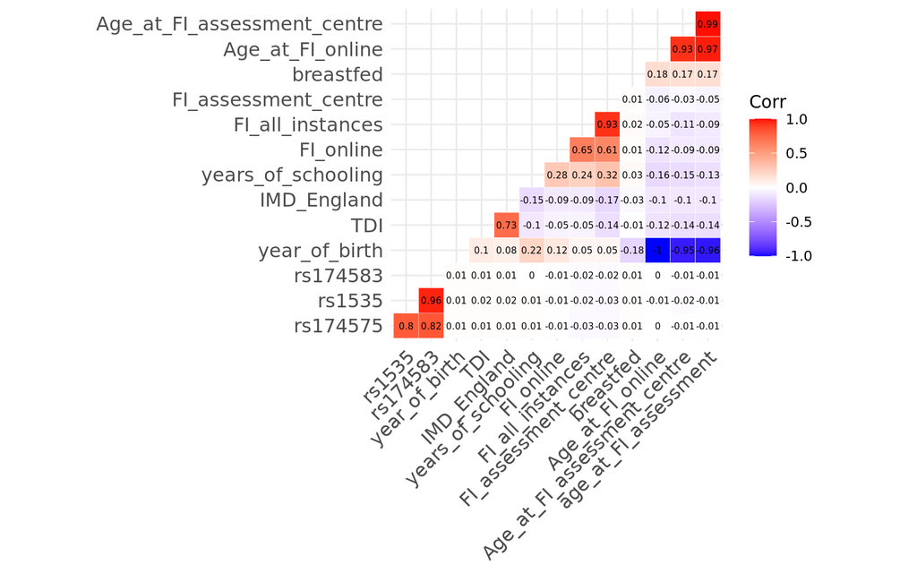

### 4.1.1 Breastfeeding and IQ

There is evidence from the previous literature that breastfeeding might be associated with IQ Hartwig et al. (2018). To test this hypothesis, we fit $Y \sim breastfeeding + sex + age + TDI + \sum^{10}_{n=1}PC_{n}$ , where $breastfeeding$ is coded as the reference level:

```
##
## Call:
## lm(formula = formula_bf_iq_agesex, data = .)
##
## Residuals:
##     Min      1Q  Median      3Q     Max
## -7.1108 -1.5540  0.1376  1.3135  6.6040
##
## Coefficients:
##                             Estimate Std. Error t value Pr(>|t|)
## (Intercept)                 7.926366   0.068980 114.908  < 2e-16 ***
## breastfed_as_babyBottlefed -0.115867   0.023105  -5.015 5.32e-07 ***
## breastfed_as_babyMissing   -0.107479   0.022907  -4.692 2.71e-06 ***
## sexFemale                  -0.307742   0.017987 -17.109  < 2e-16 ***
## age_at_FI_assessment       -0.016645   0.001156 -14.396  < 2e-16 ***
## FI_scaleOnline             -1.081336   0.025895 -41.758  < 2e-16 ***
## ---
## Signif. codes:  0 '***' 0.001 '**' 0.01 '*' 0.05 '.' 0.1 ' ' 1
##
## Residual standard error: 2.055 on 53930 degrees of freedom
##   (351611 observations deleted due to missingness)
## Multiple R-squared:  0.04464,    Adjusted R-squared:  0.04455
## F-statistic:   504 on 5 and 53930 DF,  p-value: < 2.2e-16
```

```
##
## Call:
## lm(formula = formula_bf_iq_tdi, data = .)
##
## Residuals:
##     Min      1Q  Median      3Q     Max
## -7.0975 -1.4947  0.0712  1.3898  6.8589
##
## Coefficients:
##                             Estimate Std. Error t value Pr(>|t|)
## (Intercept)                 8.332729   0.069604 119.716  < 2e-16 ***
## breastfed_as_babyBottlefed -0.168098   0.023425  -7.176 7.26e-13 ***
## breastfed_as_babyMissing   -0.083051   0.023246  -3.573 0.000354 ***
## sexFemale                  -0.308540   0.018257 -16.900  < 2e-16 ***
## age_at_FI_assessment       -0.027441   0.001166 -23.535  < 2e-16 ***
## Townsend_deprivation_index -0.045509   0.003318 -13.715  < 2e-16 ***
## ---
## Signif. codes:  0 '***' 0.001 '**' 0.01 '*' 0.05 '.' 0.1 ' ' 1
##
## Residual standard error: 2.084 on 53865 degrees of freedom
##   (351676 observations deleted due to missingness)
## Multiple R-squared:  0.01717,    Adjusted R-squared:  0.01708
## F-statistic: 188.2 on 5 and 53865 DF,  p-value: < 2.2e-16
```

```
##
## Call:
## lm(formula = formula_bf_iq_tdi_pcs, data = .)
##
## Residuals:
##    Min     1Q Median     3Q    Max
## -7.207 -1.456  0.034  1.340  7.702
##
## Coefficients:
##                              Estimate Std. Error t value Pr(>|t|)
## (Intercept)                 8.7513017  0.0689546 126.914  < 2e-16 ***
## breastfed_as_babyBottlefed -0.2528382  0.0231141 -10.939  < 2e-16 ***
## breastfed_as_babyMissing   -0.1201606  0.0228519  -5.258 1.46e-07 ***
## sexFemale                  -0.3065366  0.0179240 -17.102  < 2e-16 ***
## age_at_FI_assessment       -0.0346847  0.0011557 -30.013  < 2e-16 ***
## Townsend_deprivation_index -0.0252642  0.0033016  -7.652 2.01e-14 ***
## principal_component_1      -0.0069208  0.0002232 -31.002  < 2e-16 ***
## principal_component_2       0.0074140  0.0003601  20.589  < 2e-16 ***
## principal_component_3      -0.0054818  0.0006692  -8.191 2.64e-16 ***
## principal_component_4      -0.0013270  0.0008321  -1.595  0.11077
## principal_component_5      -0.0084440  0.0012449  -6.783 1.19e-11 ***
## principal_component_6      -0.0266090  0.0020305 -13.105  < 2e-16 ***
## principal_component_7      -0.0166010  0.0017802  -9.325  < 2e-16 ***
## principal_component_8      -0.0284015  0.0018726 -15.167  < 2e-16 ***
## principal_component_9      -0.0068850  0.0021475  -3.206  0.00135 **
## principal_component_10      0.0065116  0.0024015   2.711  0.00670 **
## ---
## Signif. codes:  0 '***' 0.001 '**' 0.01 '*' 0.05 '.' 0.1 ' ' 1
##
## Residual standard error: 2.044 on 53855 degrees of freedom
##   (351676 observations deleted due to missingness)
## Multiple R-squared:  0.05485,    Adjusted R-squared:  0.05459
## F-statistic: 208.4 on 15 and 53855 DF,  p-value: < 2.2e-16
```

```
##
## Call:
## lm(formula = formula_bf_ea_tdi, data = .)
##
## Residuals:
##     Min      1Q  Median      3Q     Max
## -12.147  -4.876   1.548   4.277  10.156
##
## Coefficients:
##                              Estimate Std. Error t value Pr(>|t|)
## (Intercept)                -2.648e+02  1.916e+00 -138.17   <2e-16 ***
## breastfed_as_babyBottlefed -7.431e-01  2.000e-02  -37.16   <2e-16 ***
## breastfed_as_babyMissing   -1.065e+00  1.927e-02  -55.28   <2e-16 ***
## sexFemale                  -7.867e-01  1.563e-02  -50.33   <2e-16 ***
## yob                         1.437e-01  9.818e-04  146.36   <2e-16 ***
## Townsend_deprivation_index -1.987e-01  2.513e-03  -79.07   <2e-16 ***
## ---
## Signif. codes:  0 '***' 0.001 '**' 0.01 '*' 0.05 '.' 0.1 ' ' 1
##
## Residual standard error: 4.89 on 400201 degrees of freedom
##   (5340 observations deleted due to missingness)
## Multiple R-squared:  0.07552,    Adjusted R-squared:  0.07551
## F-statistic:  6539 on 5 and 400201 DF,  p-value: < 2.2e-16
```

```
##
## Call:
## lm(formula = formula_bf_ea_tdi_pcs, data = .)
##
## Residuals:
##     Min      1Q  Median      3Q     Max
## -13.006  -4.835   1.500   4.263  10.386
##
## Coefficients:
##                              Estimate Std. Error  t value Pr(>|t|)
## (Intercept)                -2.609e+02  1.929e+00 -135.256  < 2e-16 ***
## breastfed_as_babyBottlefed -7.043e-01  2.016e-02  -34.942  < 2e-16 ***
## breastfed_as_babyMissing   -1.038e+00  1.929e-02  -53.823  < 2e-16 ***
## sexFemale                  -8.049e-01  1.560e-02  -51.599  < 2e-16 ***
## yob                         1.417e-01  9.885e-04  143.365  < 2e-16 ***
## Townsend_deprivation_index -2.089e-01  2.587e-03  -80.726  < 2e-16 ***
## principal_component_1       1.692e-03  1.418e-04   11.929  < 2e-16 ***
## principal_component_2      -6.698e-04  2.674e-04   -2.505 0.012239 *
## principal_component_3      -1.657e-03  5.032e-04   -3.294 0.000988 ***
## principal_component_4      -2.656e-02  7.214e-04  -36.809  < 2e-16 ***
## principal_component_5       3.776e-03  1.033e-03    3.655 0.000257 ***
## principal_component_6       1.182e-02  1.473e-03    8.024 1.03e-15 ***
## principal_component_7      -3.790e-02  1.491e-03  -25.421  < 2e-16 ***
## principal_component_8       7.713e-03  1.540e-03    5.009 5.48e-07 ***
## principal_component_9      -2.087e-02  1.726e-03  -12.093  < 2e-16 ***
## principal_component_10     -1.815e-02  1.814e-03  -10.009  < 2e-16 ***
## ---
## Signif. codes:  0 '***' 0.001 '**' 0.01 '*' 0.05 '.' 0.1 ' ' 1
##
## Residual standard error: 4.875 on 400191 degrees of freedom
##   (5340 observations deleted due to missingness)
## Multiple R-squared:  0.08129,    Adjusted R-squared:  0.08125
## F-statistic:  2361 on 15 and 400191 DF,  p-value: < 2.2e-16
```

## 4.2 FADS and breastfeeding

We also want to check whether FADS and breastfeeding are associated. They should not, as the change in allele dosage should not be different between breastfed and bottlefed individuals.

```
##
## Call:
## glm(formula = breastfeeding_rs1535, family = binomial, data = .)
##
## Deviance Residuals:
##     Min       1Q   Median       3Q      Max
## -1.1725  -0.8281  -0.7825   1.4426   2.5945
##
## Coefficients:
##                          Estimate Std. Error  z value Pr(>|z|)
## (Intercept)            -9.863e-01  9.028e-03 -109.251  < 2e-16 ***
## rs1535_A               -5.481e-06  6.052e-03   -0.001    0.999
## principal_component_1  -5.806e-03  1.255e-04  -46.253  < 2e-16 ***
## principal_component_2   3.153e-03  1.904e-04   16.557  < 2e-16 ***
## principal_component_3  -9.814e-03  3.545e-04  -27.683  < 2e-16 ***
## principal_component_4   2.469e-03  4.189e-04    5.893 3.79e-09 ***
## principal_component_5   2.295e-02  5.248e-04   43.732  < 2e-16 ***
## principal_component_6  -1.032e-02  9.734e-04  -10.605  < 2e-16 ***
## principal_component_7  -3.862e-03  8.723e-04   -4.427 9.54e-06 ***
## principal_component_8  -7.949e-03  9.267e-04   -8.579  < 2e-16 ***
## principal_component_9  -1.036e-03  8.800e-04   -1.177    0.239
## principal_component_10  6.790e-03  1.197e-03    5.670 1.42e-08 ***
## ---
## Signif. codes:  0 '***' 0.001 '**' 0.01 '*' 0.05 '.' 0.1 ' ' 1
##
## (Dispersion parameter for binomial family taken to be 1)
##
##     Null deviance: 365725  on 309817  degrees of freedom
## Residual deviance: 358252  on 309806  degrees of freedom
##   (95729 observations deleted due to missingness)
## AIC: 358276
##
## Number of Fisher Scoring iterations: 5
```

```
##
## Call:
## glm(formula = breastfeeding_rs174575, family = binomial, data = .)
##
## Deviance Residuals:
##     Min       1Q   Median       3Q      Max
## -1.1711  -0.8281  -0.7825   1.4424   2.5954
##
## Coefficients:
##                          Estimate Std. Error z value Pr(>|z|)
## (Intercept)            -0.9785252  0.0103341 -94.689  < 2e-16 ***
## rs174575_C             -0.0053217  0.0064616  -0.824    0.410
## principal_component_1  -0.0058034  0.0001254 -46.288  < 2e-16 ***
## principal_component_2   0.0031458  0.0001905  16.511  < 2e-16 ***
## principal_component_3  -0.0098052  0.0003536 -27.728  < 2e-16 ***
## principal_component_4   0.0024670  0.0004189   5.889 3.89e-09 ***
## principal_component_5   0.0229435  0.0005249  43.714  < 2e-16 ***
## principal_component_6  -0.0103276  0.0009733 -10.611  < 2e-16 ***
## principal_component_7  -0.0038713  0.0008724  -4.438 9.09e-06 ***
## principal_component_8  -0.0079405  0.0009267  -8.568  < 2e-16 ***
## principal_component_9  -0.0010492  0.0008801  -1.192    0.233
## principal_component_10  0.0067870  0.0011974   5.668 1.44e-08 ***
## ---
## Signif. codes:  0 '***' 0.001 '**' 0.01 '*' 0.05 '.' 0.1 ' ' 1
##
## (Dispersion parameter for binomial family taken to be 1)
##
##     Null deviance: 365725  on 309817  degrees of freedom
## Residual deviance: 358252  on 309806  degrees of freedom
##   (95729 observations deleted due to missingness)
## AIC: 358276
##
## Number of Fisher Scoring iterations: 5
```

```
##
## Call:
## glm(formula = breastfeeding_rs174583, family = binomial, data = .)
##
## Deviance Residuals:
##     Min       1Q   Median       3Q      Max
## -1.1717  -0.8281  -0.7825   1.4424   2.5950
##
## Coefficients:
##                          Estimate Std. Error  z value Pr(>|z|)
## (Intercept)            -0.9831883  0.0088675 -110.875  < 2e-16 ***
## rs174583_C             -0.0024015  0.0060145   -0.399    0.690
## principal_component_1  -0.0058049  0.0001254  -46.304  < 2e-16 ***
## principal_component_2   0.0031533  0.0001904   16.564  < 2e-16 ***
## principal_component_3  -0.0098035  0.0003544  -27.662  < 2e-16 ***
## principal_component_4   0.0024692  0.0004189    5.894 3.76e-09 ***
## principal_component_5   0.0229486  0.0005248   43.728  < 2e-16 ***
## principal_component_6  -0.0103268  0.0009733  -10.610  < 2e-16 ***
## principal_component_7  -0.0038642  0.0008723   -4.430 9.43e-06 ***
## principal_component_8  -0.0079480  0.0009266   -8.577  < 2e-16 ***
## principal_component_9  -0.0010403  0.0008800   -1.182    0.237
## principal_component_10  0.0067870  0.0011974    5.668 1.45e-08 ***
## ---
## Signif. codes:  0 '***' 0.001 '**' 0.01 '*' 0.05 '.' 0.1 ' ' 1
##
## (Dispersion parameter for binomial family taken to be 1)
##
##     Null deviance: 365725  on 309817  degrees of freedom
## Residual deviance: 358252  on 309806  degrees of freedom
##   (95729 observations deleted due to missingness)
## AIC: 358276
##
## Number of Fisher Scoring iterations: 5
```

## 4.3 Replicating Caspi et al. (2007)’s analysis

We attempt to replicate the model shown in Caspi et al. (2007) as closely as possible by fitting $Y \sim SNP + breasfeeding + SNP \times breastfeeding + SES$.

Breastfeeding is coded once again as 1 = breastfed and 0 = bottlefed.

```
##
## Call:
## lm(formula = FI_all ~ rs1535_A + breastfed_as_baby + rs1535_A *
##     breastfed_as_baby + Townsend_deprivation_index + FI_scale +
##     age_at_FI_assessment, data = .)
##
## Residuals:
##     Min      1Q  Median      3Q     Max
## -7.0199 -1.5908  0.1236  1.2854  6.5617
##
## Coefficients:
##                             Estimate Std. Error t value Pr(>|t|)
## (Intercept)                 7.618876   0.081884  93.044  < 2e-16 ***
## rs1535_A                   -0.005527   0.029181  -0.189  0.84977
## breastfed_as_baby           0.274923   0.049912   5.508 3.65e-08 ***
## Townsend_deprivation_index -0.046956   0.003669 -12.797  < 2e-16 ***
## FI_scaleOnline             -1.074393   0.028958 -37.101  < 2e-16 ***
## age_at_FI_assessment       -0.017890   0.001296 -13.808  < 2e-16 ***
## rs1535_A:breastfed_as_baby -0.104652   0.033832  -3.093  0.00198 **
## ---
## Signif. codes:  0 '***' 0.001 '**' 0.01 '*' 0.05 '.' 0.1 ' ' 1
##
## Residual standard error: 2.059 on 42803 degrees of freedom
##   (362737 observations deleted due to missingness)
## Multiple R-squared:  0.04347,    Adjusted R-squared:  0.04334
## F-statistic: 324.2 on 6 and 42803 DF,  p-value: < 2.2e-16
```

```
##
## Call:
## lm(formula = FI_all ~ rs174575_C + breastfed_as_baby + rs174575_C *
##     breastfed_as_baby + Townsend_deprivation_index + FI_scale +
##     age_at_FI_assessment, data = .)
##
## Residuals:
##     Min      1Q  Median      3Q     Max
## -6.9343 -1.5887  0.1243  1.2867  6.5860
##
## Coefficients:
##                               Estimate Std. Error t value Pr(>|t|)
## (Intercept)                   7.682109   0.085191  90.175  < 2e-16 ***
## rs174575_C                   -0.050787   0.031090  -1.634   0.1024
## breastfed_as_baby             0.250439   0.057153   4.382 1.18e-05 ***
## Townsend_deprivation_index   -0.047022   0.003669 -12.816  < 2e-16 ***
## FI_scaleOnline               -1.074114   0.028955 -37.096  < 2e-16 ***
## age_at_FI_assessment         -0.017843   0.001295 -13.773  < 2e-16 ***
## rs174575_C:breastfed_as_baby -0.077230   0.036079  -2.141   0.0323 *
## ---
## Signif. codes:  0 '***' 0.001 '**' 0.01 '*' 0.05 '.' 0.1 ' ' 1
##
## Residual standard error: 2.059 on 42803 degrees of freedom
##   (362737 observations deleted due to missingness)
## Multiple R-squared:  0.0437, Adjusted R-squared:  0.04357
## F-statistic:   326 on 6 and 42803 DF,  p-value: < 2.2e-16
```

Caspi et al. (2007) ’s analysis was done using a single cohort with the same age and balanced for sex, so we also try to repeat the model adjusting for age and sex.

```
##
## Call:
## lm(formula = FI_all ~ rs1535_A + breastfed_as_baby + rs1535_A *
##     breastfed_as_baby + Townsend_deprivation_index + sex + yob,
##     data = .)
##
## Residuals:
##     Min      1Q  Median      3Q     Max
## -7.1862 -1.5240  0.1424  1.3914  6.7373
##
## Coefficients:
##                              Estimate Std. Error t value Pr(>|t|)
## (Intercept)                -27.036677   2.624266 -10.303  < 2e-16 ***
## rs1535_A                    -0.009284   0.029687  -0.313  0.75449
## breastfed_as_baby            0.268522   0.050804   5.286 1.26e-07 ***
## Townsend_deprivation_index  -0.038638   0.003725 -10.374  < 2e-16 ***
## sexFemale                   -0.252674   0.020600 -12.265  < 2e-16 ***
## yob                          0.017225   0.001342  12.837  < 2e-16 ***
## rs1535_A:breastfed_as_baby  -0.095865   0.034420  -2.785  0.00535 **
## ---
## Signif. codes:  0 '***' 0.001 '**' 0.01 '*' 0.05 '.' 0.1 ' ' 1
##
## Residual standard error: 2.095 on 42803 degrees of freedom
##   (362737 observations deleted due to missingness)
## Multiple R-squared:  0.01011,    Adjusted R-squared:  0.009975
## F-statistic: 72.88 on 6 and 42803 DF,  p-value: < 2.2e-16
```

[output not shown]

There are a few important differences between UK Biobank and the studies in Caspi et al. (2007) that might also explain the results:

- Standardised childhood IQ test (Dunedin and E-risk) vs unstandardised adult IQ test (UK Biobank);
- Measure of individual SES based on parental occupation (Dunedin) vs regional deprivation (UK Biobank);
- Cohort homogeneous for age and with repeated IQ measurements (Dunedin and E-risk) vs first-instance questions at different ages (UK Biobank).

## 4.4 Proxy GxE MR

```r
caspi_plot_data <-
  # using data for table as it's the one with the hardcalled genotypes
  data_for_table %>%
  select(years_of_schooling, FI_all, sex, breastfed_as_baby, rs1535_A, rs174575_C, rs174583_C, age_at_FI_assessment, yob, starts_with("principal_component"))
```

### 4.4.1 Fluid intelligence

Modelled as $Y \sim SNP + sex + age\ at\ FI\ assessment + FI\ scale+ \sum^{10}_{n=1}PC_{n}$:

```
## $Breastfed
##
## Call:
## lm(formula = formula(paste(outcome, "~", SNP_name, "+ sex + age_at_FI_assessment + FI_scale + ",
##     paste(paste0("principal_component_", 1:10), collapse = " + "))),
##     data = x)
##
## Residuals:
##     Min      1Q  Median      3Q     Max
## -7.2417 -1.4333  0.0498  1.2412  7.2364
##
## Coefficients:
##                          Estimate Std. Error t value Pr(>|t|)
## (Intercept)             8.5540107  0.0919286  93.051  < 2e-16 ***
## rs1535_A               -0.0631031  0.0168124  -3.753 0.000175 ***
## sexFemale              -0.2561419  0.0227476 -11.260  < 2e-16 ***
## age_at_FI_assessment   -0.0270435  0.0015018 -18.007  < 2e-16 ***
## FI_scaleOnline         -1.0809093  0.0332875 -32.472  < 2e-16 ***
## principal_component_1  -0.0075320  0.0002437 -30.909  < 2e-16 ***
## principal_component_2   0.0083383  0.0004091  20.383  < 2e-16 ***
## principal_component_3  -0.0067089  0.0007597  -8.830  < 2e-16 ***
## principal_component_4   0.0011553  0.0010025   1.152 0.249132
## principal_component_5  -0.0055195  0.0016561  -3.333 0.000861 ***
## principal_component_6  -0.0304597  0.0023973 -12.706  < 2e-16 ***
## principal_component_7  -0.0178764  0.0020991  -8.516  < 2e-16 ***
## principal_component_8  -0.0293440  0.0022089 -13.285  < 2e-16 ***
## principal_component_9  -0.0006272  0.0028599  -0.219 0.826424
## principal_component_10  0.0061671  0.0027840   2.215 0.026756 *
## ---
## Signif. codes:  0 '***' 0.001 '**' 0.01 '*' 0.05 '.' 0.1 ' ' 1
##
## Residual standard error: 2.006 on 31935 degrees of freedom
##   (192007 observations deleted due to missingness)
## Multiple R-squared:  0.0976, Adjusted R-squared:  0.0972
## F-statistic: 246.7 on 14 and 31935 DF,  p-value: < 2.2e-16
##
##
## $Bottlefed
##
## Call:
```

[output cut: 54 more lines]

```
## principal_component_3  -0.0031950  0.0018901  -1.690  0.09098 .
## principal_component_4  -0.0062553  0.0021802  -2.869  0.00412 **
## principal_component_5  -0.0066412  0.0025859  -2.568  0.01023 *
## principal_component_6  -0.0198270  0.0050200  -3.950 7.88e-05 ***
## principal_component_7  -0.0104998  0.0046834  -2.242  0.02499 *
## principal_component_8  -0.0192809  0.0046961  -4.106 4.06e-05 ***
## principal_component_9  -0.0024437  0.0044556  -0.548  0.58339
## principal_component_10  0.0048196  0.0062603   0.770  0.44140
## ---
## Signif. codes:  0 '***' 0.001 '**' 0.01 '*' 0.05 '.' 0.1 ' ' 1
##
## Residual standard error: 2.012 on 11061 degrees of freedom
##   (84653 observations deleted due to missingness)
## Multiple R-squared:  0.07498,    Adjusted R-squared:  0.07381
## F-statistic: 64.04 on 14 and 11061 DF,  p-value: < 2.2e-16
```

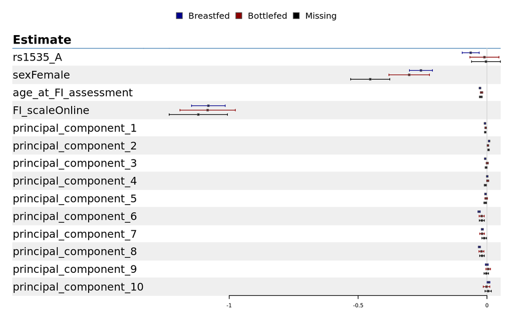

[output not shown]

[output cut: 54 more lines]

[output not shown]

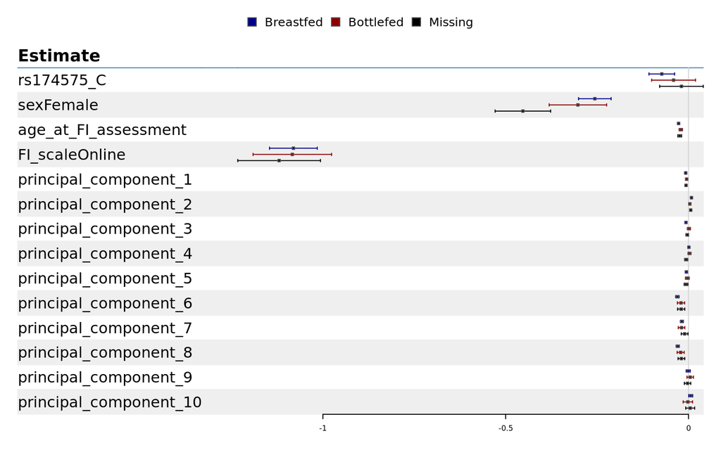

```
## $Breastfed
##
## Call:
## lm(formula = formula(paste(outcome, "~", SNP_name, "+ sex + age_at_FI_assessment + FI_scale + ",
##     paste(paste0("principal_component_", 1:10), collapse = " + "))),
##     data = x)
##
## Residuals:
##     Min      1Q  Median      3Q     Max
## -7.2417 -1.4334  0.0491  1.2406  7.2376
##
## Coefficients:
##                          Estimate Std. Error t value Pr(>|t|)
## (Intercept)             8.5568341  0.0917907  93.221  < 2e-16 ***
## rs174583_C             -0.0661837  0.0166603  -3.973 7.13e-05 ***
## sexFemale              -0.2562590  0.0227462 -11.266  < 2e-16 ***
## age_at_FI_assessment   -0.0270459  0.0015018 -18.009  < 2e-16 ***
## FI_scaleOnline         -1.0804867  0.0332873 -32.459  < 2e-16 ***
## principal_component_1  -0.0075687  0.0002431 -31.139  < 2e-16 ***
## principal_component_2   0.0083212  0.0004090  20.346  < 2e-16 ***
## principal_component_3  -0.0067152  0.0007592  -8.845  < 2e-16 ***
## principal_component_4   0.0011845  0.0010025   1.182 0.237398
## principal_component_5  -0.0055221  0.0016561  -3.334 0.000856 ***
## principal_component_6  -0.0304654  0.0023972 -12.709  < 2e-16 ***
## principal_component_7  -0.0178787  0.0020991  -8.517  < 2e-16 ***
## principal_component_8  -0.0293307  0.0022088 -13.279  < 2e-16 ***
## principal_component_9  -0.0006181  0.0028598  -0.216 0.828881
## principal_component_10  0.0061424  0.0027840   2.206 0.027368 *
## ---
## Signif. codes:  0 '***' 0.001 '**' 0.01 '*' 0.05 '.' 0.1 ' ' 1
##
## Residual standard error: 2.006 on 31935 degrees of freedom
##   (192007 observations deleted due to missingness)
## Multiple R-squared:  0.09765,    Adjusted R-squared:  0.09725
## F-statistic: 246.8 on 14 and 31935 DF,  p-value: < 2.2e-16
##
##
## $Bottlefed
##
## Call:
```

[output cut: 54 more lines]

```
## principal_component_3  -0.0032033  0.0018907  -1.694  0.09024 .
## principal_component_4  -0.0062553  0.0021802  -2.869  0.00412 **
## principal_component_5  -0.0066406  0.0025859  -2.568  0.01024 *
## principal_component_6  -0.0198175  0.0050199  -3.948 7.94e-05 ***
## principal_component_7  -0.0104957  0.0046834  -2.241  0.02504 *
## principal_component_8  -0.0192811  0.0046961  -4.106 4.06e-05 ***
## principal_component_9  -0.0024384  0.0044555  -0.547  0.58420
## principal_component_10  0.0048295  0.0062601   0.771  0.44045
## ---
## Signif. codes:  0 '***' 0.001 '**' 0.01 '*' 0.05 '.' 0.1 ' ' 1
##
## Residual standard error: 2.012 on 11061 degrees of freedom
##   (84653 observations deleted due to missingness)
## Multiple R-squared:  0.07498,    Adjusted R-squared:  0.07381
## F-statistic: 64.04 on 14 and 11061 DF,  p-value: < 2.2e-16
```

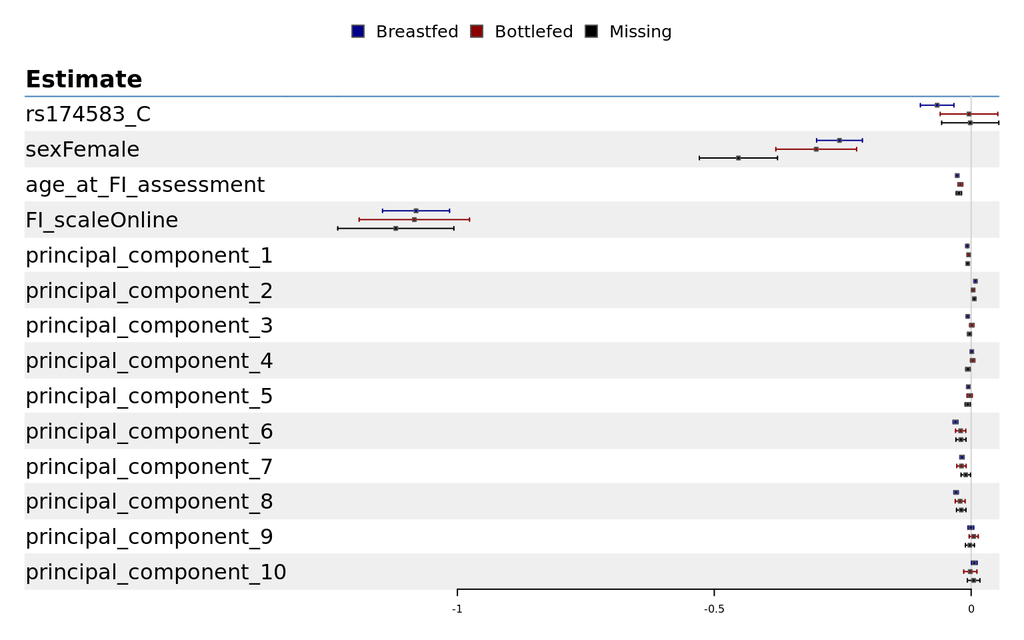

### 4.4.2 Educational attainment

Modelled as $Y \sim SNP + sex + year\ of\ birth + \sum^{10}_{n=1}PC_{n}$:

```
## $Breastfed
##
## Call:
## lm(formula = formula(paste(outcome, "~", SNP_name, "+ sex + yob + ",
##     paste(paste0("principal_component_", 1:10), collapse = " + "))),
##     data = x)
##
## Residuals:
##     Min      1Q  Median      3Q     Max
## -13.086  -4.603   1.840   4.139   7.748
##
## Coefficients:
##                          Estimate Std. Error  t value Pr(>|t|)
## (Intercept)            -2.624e+02  2.569e+00 -102.155  < 2e-16 ***
## rs1535_A                1.848e-02  1.542e-02    1.199  0.23070
## sexFemale              -7.125e-01  2.059e-02  -34.605  < 2e-16 ***
## yob                     1.426e-01  1.317e-03  108.306  < 2e-16 ***
## principal_component_1  -7.154e-04  1.535e-04   -4.660 3.16e-06 ***
## principal_component_2   4.094e-04  3.090e-04    1.325  0.18511
## principal_component_3  -3.584e-03  5.849e-04   -6.127 8.96e-10 ***
## principal_component_4  -2.371e-02  9.192e-04  -25.789  < 2e-16 ***
## principal_component_5  -7.560e-03  1.429e-03   -5.289 1.23e-07 ***
## principal_component_6   4.873e-03  1.685e-03    2.892  0.00382 **
## principal_component_7  -3.930e-02  1.826e-03  -21.523  < 2e-16 ***
## principal_component_8  -2.322e-05  1.851e-03   -0.013  0.98999
## principal_component_9  -1.939e-02  2.369e-03   -8.183 2.78e-16 ***
## principal_component_10 -1.125e-02  2.117e-03   -5.314 1.08e-07 ***
## ---
## Signif. codes:  0 '***' 0.001 '**' 0.01 '*' 0.05 '.' 0.1 ' ' 1
##
## Residual standard error: 4.813 on 221806 degrees of freedom
##   (2137 observations deleted due to missingness)
## Multiple R-squared:  0.06046,    Adjusted R-squared:  0.0604
## F-statistic:  1098 on 13 and 221806 DF,  p-value: < 2.2e-16
##
##
## $Bottlefed
##
## Call:
## lm(formula = formula(paste(outcome, "~", SNP_name, "+ sex + yob + ",
```

[output cut: 51 more lines]

```
## principal_component_3  -4.649e-03  1.370e-03  -3.394 0.000689 ***
## principal_component_4  -2.623e-02  1.769e-03 -14.824  < 2e-16 ***
## principal_component_5  -8.815e-03  2.150e-03  -4.100 4.14e-05 ***
## principal_component_6   4.105e-03  4.082e-03   1.006 0.314598
## principal_component_7  -3.368e-02  3.770e-03  -8.932  < 2e-16 ***
## principal_component_8   3.725e-03  3.926e-03   0.949 0.342793
## principal_component_9  -3.363e-02  3.754e-03  -8.957  < 2e-16 ***
## principal_component_10 -1.883e-02  4.763e-03  -3.953 7.71e-05 ***
## ---
## Signif. codes:  0 '***' 0.001 '**' 0.01 '*' 0.05 '.' 0.1 ' ' 1
##
## Residual standard error: 5.158 on 93666 degrees of freedom
##   (2049 observations deleted due to missingness)
## Multiple R-squared:  0.05365,    Adjusted R-squared:  0.05351
## F-statistic: 408.4 on 13 and 93666 DF,  p-value: < 2.2e-16
```

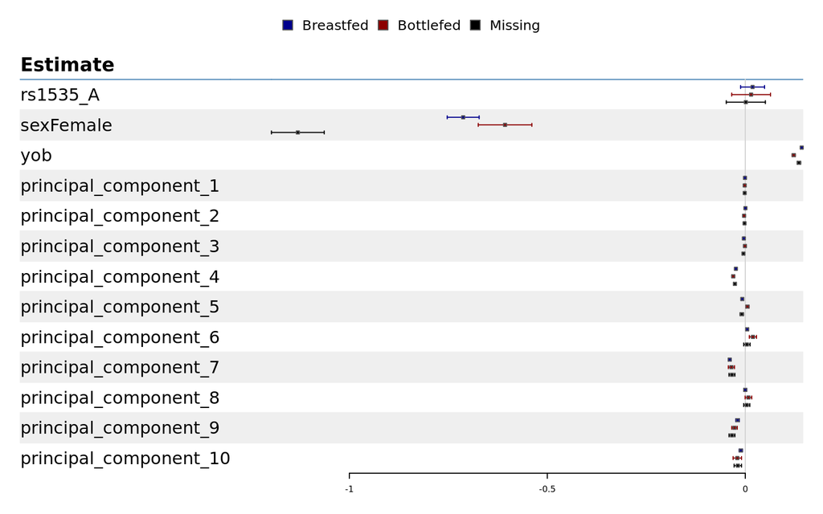

[output not shown]

[output cut: 51 more lines]

[output not shown]

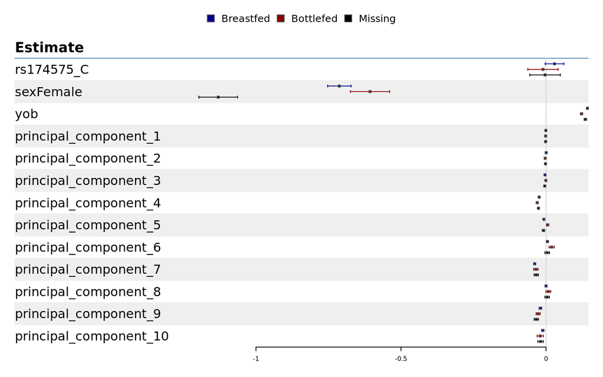

```
## $Breastfed
##
## Call:
## lm(formula = formula(paste(outcome, "~", SNP_name, "+ sex + yob + ",
##     paste(paste0("principal_component_", 1:10), collapse = " + "))),
##     data = x)
##
## Residuals:
##     Min      1Q  Median      3Q     Max
## -13.086  -4.603   1.840   4.140   7.747
##
## Coefficients:
##                          Estimate Std. Error  t value Pr(>|t|)
## (Intercept)            -2.624e+02  2.569e+00 -102.155  < 2e-16 ***
## rs174583_C              1.961e-02  1.524e-02    1.286  0.19828
## sexFemale              -7.125e-01  2.059e-02  -34.605  < 2e-16 ***
## yob                     1.426e-01  1.317e-03  108.307  < 2e-16 ***
## principal_component_1  -7.028e-04  1.526e-04   -4.604 4.14e-06 ***
## principal_component_2   4.162e-04  3.088e-04    1.348  0.17769
## principal_component_3  -3.585e-03  5.845e-04   -6.134 8.60e-10 ***
## principal_component_4  -2.371e-02  9.192e-04  -25.794  < 2e-16 ***
## principal_component_5  -7.560e-03  1.429e-03   -5.289 1.23e-07 ***
## principal_component_6   4.877e-03  1.685e-03    2.895  0.00379 **
## principal_component_7  -3.929e-02  1.826e-03  -21.517  < 2e-16 ***
## principal_component_8  -1.880e-05  1.850e-03   -0.010  0.99189
## principal_component_9  -1.939e-02  2.369e-03   -8.184 2.76e-16 ***
## principal_component_10 -1.125e-02  2.117e-03   -5.313 1.08e-07 ***
## ---
## Signif. codes:  0 '***' 0.001 '**' 0.01 '*' 0.05 '.' 0.1 ' ' 1
##
## Residual standard error: 4.813 on 221806 degrees of freedom
##   (2137 observations deleted due to missingness)
## Multiple R-squared:  0.06046,    Adjusted R-squared:  0.06041
## F-statistic:  1098 on 13 and 221806 DF,  p-value: < 2.2e-16
##
##
## $Bottlefed
##
## Call:
## lm(formula = formula(paste(outcome, "~", SNP_name, "+ sex + yob + ",
```

[output cut: 51 more lines]

```
## principal_component_3  -4.652e-03  1.370e-03  -3.397 0.000682 ***
## principal_component_4  -2.623e-02  1.769e-03 -14.824  < 2e-16 ***
## principal_component_5  -8.814e-03  2.150e-03  -4.099 4.15e-05 ***
## principal_component_6   4.107e-03  4.082e-03   1.006 0.314308
## principal_component_7  -3.367e-02  3.770e-03  -8.932  < 2e-16 ***
## principal_component_8   3.724e-03  3.926e-03   0.949 0.342833
## principal_component_9  -3.363e-02  3.754e-03  -8.957  < 2e-16 ***
## principal_component_10 -1.883e-02  4.763e-03  -3.953 7.72e-05 ***
## ---
## Signif. codes:  0 '***' 0.001 '**' 0.01 '*' 0.05 '.' 0.1 ' ' 1
##
## Residual standard error: 5.158 on 93666 degrees of freedom
##   (2049 observations deleted due to missingness)
## Multiple R-squared:  0.05365,    Adjusted R-squared:  0.05351
## F-statistic: 408.4 on 13 and 93666 DF,  p-value: < 2.2e-16
```

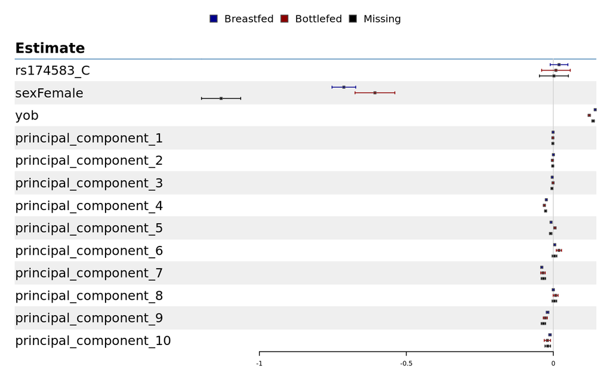

# References

Carter, Alice R, Sean Harrison, Dipender Gill, George Davey Smith, Amy E Taylor, Laura D Howe, and Neil M Davies. 2022. “Educational Attainment as a Modifier for the Effect of Polygenic Scores for Cardiovascular Risk Factors: Cross-Sectional and Prospective Analysis of UK Biobank.” *International Journal of Epidemiology* 51 (3): 885–97. https://doi.org/10.1093/ije/dyac002.

Caspi, Avshalom, Benjamin Williams, Julia Kim-Cohen, Ian W. Craig, Barry J. Milne, Richie Poulton, Leonard C. Schalkwyk, Alan Taylor, Helen Werts, and Terrie E. Moffitt. 2007. “Moderation of Breastfeeding Effects on the IQ by Genetic Variation in Fatty Acid Metabolism.” *Proceedings of the National Academy of Sciences* 104 (47): 18860–65. https://doi.org/10.1073/pnas.0704292104.

Hartwig, Fernando Pires, Neil Martin Davies, Bernardo Lessa Horta, Tarunveer S Ahluwalia, Hans Bisgaard, Klaus Bønnelykke, Avshalom Caspi, et al. 2018. “Effect Modification of *FADS2* Polymorphisms on the Association Between Breastfeeding and Intelligence: Results from a Collaborative Meta-Analysis.” *International Journal of Epidemiology* 48 (1): 45–57. https://doi.org/10.1093/ije/dyy273.